# Learning and Predicting from Video Game Sales History

## Learning and Predicting from Video Game Sales History

**A project by Martin Blurton-Jones for CMSC320**

**Imports:** \ The most important libraries we will be using are: \ [BeautifulSoup](https://beautiful-soup-4.readthedocs.io/en/latest/), an incredibly helpful library for scraping data from html websites and reading them into nicer datastructures. \ [Numpy](https://numpy.org/doc/stable/user/whatisnumpy.html), a library that provides many essential mathematical functions and processes. \ [Pandas](https://pandas.pydata.org/pandas-docs/stable/getting_started/index.html), a library that provides very useful datastructures for storing tables in rows and columns. \ [Seaborn](https://seaborn.pydata.org/introduction.html), an elegant and effective way to graph and plot various forms of data. \ [Scikit-Learn](https://scikit-learn.org/stable/), a powerful tool for implementing machine learning in a project, including everything from preparing the training data to providing models to train.

```python
import requests
from bs4 import BeautifulSoup
import numpy as np
import pandas as pd
import re
import datetime
import seaborn as sns
import matplotlib.pyplot as plt
import sklearn
from sklearn.model_selection import train_test_split
from sklearn.ensemble import RandomForestClassifier
from sklearn.neighbors import KNeighborsClassifier
from sklearn.model_selection import cross_validate
from sklearn.model_selection import KFold
from sklearn.model_selection import GridSearchCV
```

## Parsing Onwards

The first step of analyzing data is gathering the data together. \ The table that this project will be using is available at [vgchartz.com](https://www.vgchartz.com/gamedb/). \ \ **Reading from the site:** \ While BeautifulSoup allows us to read a lot of the data directly from the table into a nice pandas dataframe, there are some things about the table that make it difficult to do so. First, the maximum size for each page is 200 results, meaning each page must be parsed individually and then combined into one big dataframe. As for how many pages will be counted, that can be set with the pageCount variable (for performance reasons I reccomend about 10-15 pages). The next issue is that the table includes a consoles entry, which is a helpful piece of data to have about a game. However, each entry is actually a tiny icon that represents a console. To account for this, we can look at the url of the image that is called on each console listing, and then, using a regular expression, we can parse the part of the url that contains the name of the console.

```python
#Define the number of pages to scrape (each page has 200 listings, there are 309 pages)
#Lower numbers are better/recommended if processing power is limited
#25 gives about 5000 listings (hard)
#10 gives about 2000 listings (medium)
#5 gives about 1000 listings (easy)
pageCount = 10

#Prepare the dataframe that will hold all the scraped data
vgData = pd.DataFrame()

#Go through the table page by page
for page in (range(1, pageCount + 1)):
    #Print out the current page to keep track of progress
    print("On page: " + str(page))

    #Creating the URL to get the current page of the table
    vgchartz = requests.get('https://www.vgchartz.com/games/games.php?page=' + str(page) + '&results=200&order=TotalSales&ownership=Both&showtotalsales=1&shownasales=1&showpalsales=1&showjapansales=1&showothersales=1&showpublisher=1&showdeveloper=1&showreleasedate=1&showlastupdate=1&showvgchartzscore=0&showcriticscore=1&showuserscore=1&showshipped=0')

    #Making the soup
    vg_soup = BeautifulSoup(vgchartz.text, 'html.parser')

    #Parsing the table from the page
    table = vg_soup.find('div',{"id":"generalBody"})

    #Reading the table into a pandas dataframe, labelling its columns
    pageData = pd.read_html(str(table))[0]
    pageData.columns = ['Pos','GamePic','Title','Console','Publisher','Developer','Critic Score','User Score', 'Total Sales', 'NA Sales', 'PAL Sales', 'Japan Sales', 'Other Sales', 'Release Date', 'Last Update', 'Misread']

    #The table uses small icons to represent which console the game belongs to,
    #So we can find each time one of the console pictures is called, read its filename, and then assign it to the right row
    consoleRE = re.compile('consoles/[0-9a-zA-Z_]+\\.png')
    consolepicsS = re.findall(consoleRE, str(table))
    consoleNames = []
    for i in consolepicsS:
        consoleNames.append(i[9:len(i)-6])
    #Replaces the empty Console column with the newly scraped values
    pageData['Console'] = consoleNames

    #Attatch this page's data to the main dataframe
    vgData = vgData.append(pageData, ignore_index=True)

#After adding each page, print the head of the dataframe to preview the newly generated table
print(vgData.head(25))
```

```
On page: 1
On page: 2
On page: 3
On page: 4
On page: 5
On page: 6
On page: 7
On page: 8
On page: 9
On page: 10
    Pos  GamePic                                         Title Console  \
0     1      NaN                                    Wii Sports     Wii
1     2      NaN                             Super Mario Bros.     NES
2     3      NaN                Mario Kart Wii Read the review     Wii
3     4      NaN             Wii Sports Resort Read the review     Wii
```

[output cut: 102 more lines]

```python
#These axis can be removed entirely as they serve no purpose
#(Pos is just the position in the table, Gamepic links to the game's box art which is irrelevant, and Misread is just erroneous)
vgData = vgData.drop(['Pos','GamePic','Misread'], axis=1)

#This function takes in a column name and for each item in that column it will remove the 'm' that indicates millions
#and converts the value into a float
def dropM(col):
    for i, row in vgData.iterrows():
        if type(vgData.at[i,col]) != float:
            vgData.at[i,col] = float(vgData.at[i, col][0:(len(vgData.at[i, col])-1)])

#The dropM function is called on each column that represents sales in the millions
dropM('Total Sales')
dropM('NA Sales')
dropM('PAL Sales')
dropM('Japan Sales')
dropM('Other Sales')

#Removes the 'Read the review' tag that was added to each title where the website had a review avaialable
for i, row in vgData.iterrows():
    vgData.at[i, 'Title'] = vgData.at[i, 'Title'].replace(' Read the review', '')

#Converts the Release Date and Last Update values into datetime objects for convenience
#Also, because the years are only 2 digits, sometimes pandas makes assumptions like '70 means 2070 instead of 1970
#This corrects for that
vgData['Release Date'] = pd.to_datetime(vgData['Release Date'], errors='coerce')
for i, row in vgData.iterrows():
    if vgData.at[i, 'Release Date'] > datetime.datetime.now():
        vgData.at[i, 'Release Date'] = vgData.at[i, 'Release Date'].replace(year = vgData.at[i, 'Release Date'].year - 100)
vgData['Last Update'] = pd.to_datetime(vgData['Last Update'], errors='coerce')
#Remove any titles with null Release Dates
vgData = vgData.drop(vgData[pd.isnull(vgData['Release Date'])].index)

#This table includes some entries representing entire series as opposed to titles and it doesn't make much sense
#to compare individual game sales to entire series (the individual members of the series are included as seperate listings)
#It also includes some listings that amalgamate a game's sales across all consoles
#but this could interfere with speculation about consoles later on, so it is easier to remove said listings
for i, row in vgData.iterrows():
    if vgData.at[i, 'Console'] == 'Series' or vgData.at[i, 'Console'] == 'All':
        vgData.drop(i)

#Print the head again now that it's nice and clean
print(vgData.head(25))
```

```
                                           Title Console  \
0                                     Wii Sports     Wii
1                              Super Mario Bros.     NES
2                                 Mario Kart Wii     Wii
3                              Wii Sports Resort     Wii
4             Pokémon Red / Green / Blue Version      GB
5                                         Tetris      GB
6                          New Super Mario Bros.      DS
7                                       Wii Play     Wii
8                      New Super Mario Bros. Wii     Wii
9                                      Duck Hunt     NES
10                                    Nintendogs      DS
11                                 Mario Kart DS      DS
12                 Pokémon Gold / Silver Version      GB
13                                       Wii Fit     Wii
```

[output cut: 92 more lines]

## Viewing the Industry as a Whole

Now that the data is settled, let's start by taking a look at the industry as a whole, as opposed to looking at individual titles, publishers, or developers. That way we can learn about general sales trends in the industry over time, get a better sense of the magnitude of the video game industry, and better understand this specific dataset.\ \ **Calculating the Yearly Stats:** \ Calculating data in terms of the year is a great way to measure the change over time. To expedite the process of totaling up several values for every year, the function "yearly_total(col, count)" will take in the name of a column and return a dataframe that contains the sum of that column for each year. \ The count parameter is just for a special case where instead of summing it just counts how many entries that column ha for each year. \ For example, yearly_total('Total Sales', False) would give a dataframe indexed by years with a column of the total sales across all titles each year. \ With this new function, we can calculate the total sales from games released each year and the total number of games created per year. \ \ **Graphing the Industry:** \ Once we have the means to calculate the totals, we can graph them to have a better look at them. In this case, we create a line graph of the total sales from games released each year, a scatterplot of each title's sales and release date, and a line graph of the total number of games released each year. \ What these graphs tell us is that there is a large climb overall, indicating there are more video games being released and sold as the industry grows. You may notice that there is a large peak just before 2010, which might seem to imply that gaming is dying out, but what it really shows is that our dataset is biased against newer entries, which have had less time to get and report clean sales estimates. Also, the scatterplot shows that there are several very strong outliers. Sometimes outside factors can affect a games' sales, for example, the highest point overall belongs to Wii Sports, which technically sold a huge ammount of copies because it was included with the Nintendo Wii.

```
[Text(0.5, 1.0, 'Total Games Created per Year'),
```

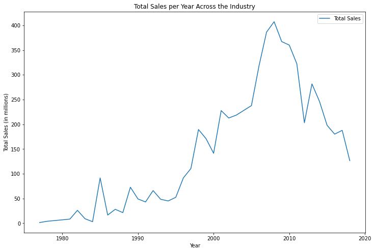

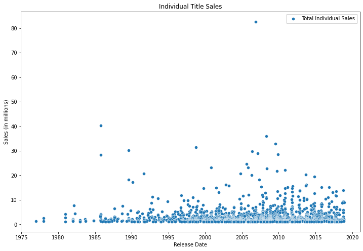

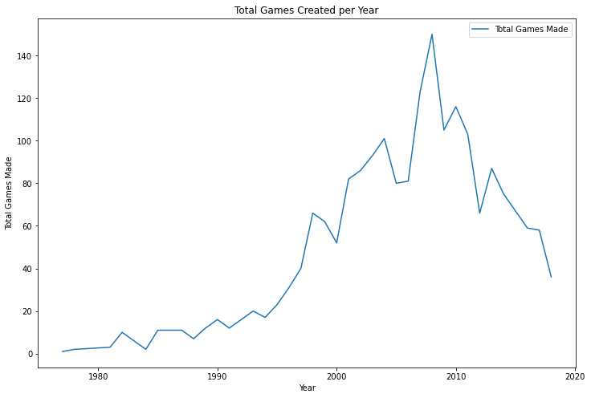

```python
#Generates a sum of the values in col for each year
#Count switches from a sum to a count of entries
def yearly_total(col, count):
    yearly = {}
    for i, row in vgData.iterrows():
        year = vgData.at[i,'Release Date'].year
        if not np.isnan(year):
            year = int(year)
            if not year in yearly:
                yearly[year] = 0
            if count:
                yearly[year] += 1
            else:
                if not np.isnan(vgData.at[i, col]):
                    yearly[year] += vgData.at[i, col]

    yearly = pd.DataFrame.from_dict(yearly, orient = 'index')
    yearly = yearly.sort_index()
    yearly.columns = [col]
    yearly.index.set_names(["Year"])
    return yearly

#Calculate the total sales from games released that year, then graph it
yearly_sales = yearly_total("Total Sales", False)
tsalesline, ax1 = plt.subplots()
tsalesline.set_size_inches(12, 8)
sns.lineplot(x = yearly_sales.index, y = yearly_sales["Total Sales"], label="Total Sales", ax=ax1).set(title="Total Sales per Year Across the Industry", xlabel="Year", ylabel="Total Sales (in millions)")

#Graph each individual title by its release date and total sales
tsalesscatter, ax2 = plt.subplots()
tsalesscatter.set_size_inches(12, 8)
sns.scatterplot(x=vgData['Release Date'],y=vgData['Total Sales'], label="Total Individual Sales", ax=ax2).set(title="Individual Title Sales", xlabel="Release Date", ylabel="Sales (in millions)")

#Calculate the total number of games released per year, then graph it
yearly_games = yearly_total("Total Sales", True)
yearly_games.columns = ["Total Games"]
tgsalesline, ax3 = plt.subplots()
tgsalesline.set_size_inches(12, 8)
sns.lineplot(x = yearly_games.index, y = yearly_games["Total Games"], label="Total Games Made", ax=ax3).set(title="Total Games Created per Year", xlabel="Year", ylabel="Total Games Made")
```

**Understanding Regional Differences:** \ Now that we've viewed how the industry has grown as a whole, we can take a closer look to see if there are any significant regional differences. \ This dataset includes three main sales regions: \ **North America**, which, as you might assume, covers North America, particularly the US, Canada, and Mexico. It is significant because of the US' strong prescence in the video game industry. \ **Japan**, which, again fairly self explanatory, covers Japan. Not unlike the US, Japan also plays a major role in both video game development and purchases, with possibly the most notable company being Nintendo, who has long been a major player in video game and video game console development. \ **PAL**, which may be less obvious. The [PAL region](https://en.wikipedia.org/wiki/PAL_region) covers multiple continents, ranging from Asia to Africa to Europe, South America, and Oceania. It was a designation that originally was used in broadcasting as those regions used the "Phase Alternating Line" television standard. Now many of the countries in the region no longer use the standard, as it was outdated (and actually significantly hindered video game performance), but in terms of video games the region is still based on the old members. \ \ Now that the regions are established, we can graph them. \ First we plot the sales per region per year. This graph shows us two things especially. One, that all three regions follow the same peak structure around 2010, which adds to the previous idea of it likely being a bias in the data as opposed to something like a spike in a specific regional market. Secondly, it shows the scale of each market, with NA being the largest market, PAL following second, and Japan ranking third. \ The second plot shows how individual titles rank in sales in each region, with the data once again showing the pre-2010 peak (which, the scatterplot shows is largely due to several high performing individual titles, such as Wii Sports).

```
[Text(0.5, 1.0, 'Individual Title Regional Sales'),
```

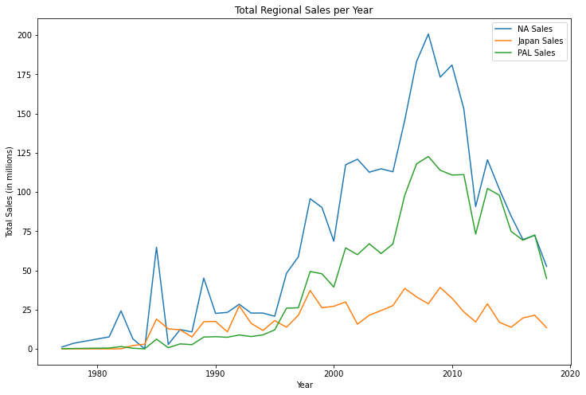

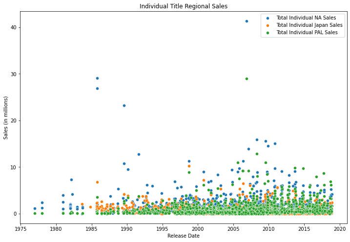

```python
#Using the yearly_total formula from before find the yearly totals for each region
yearly_NA_sales = yearly_total("NA Sales", False)
yearly_JP_sales = yearly_total("Japan Sales", False)
yearly_PAL_sales = yearly_total("PAL Sales", False)

#Set up the first graph, which plots each region's sales by year
trsalesline, ax4 = plt.subplots()
trsalesline.set_size_inches(12, 8)
sns.lineplot(x = yearly_NA_sales.index, y = yearly_NA_sales["NA Sales"], label="NA Sales", ax=ax4)
sns.lineplot(x = yearly_JP_sales.index, y = yearly_JP_sales["Japan Sales"], label="Japan Sales", ax=ax4)
sns.lineplot(x = yearly_PAL_sales.index, y = yearly_PAL_sales["PAL Sales"], label="PAL Sales", ax=ax4).set(title="Total Regional Sales per Year", xlabel="Year", ylabel="Total Sales (in millions)")

#Sets up the second graph, which plots individual titles by their release date and regional sales
trsalesscatter, ax5 = plt.subplots()
trsalesscatter.set_size_inches(12, 8)
sns.scatterplot(x=vgData['Release Date'],y=vgData['NA Sales'], label="Total Individual NA Sales", ax=ax5)
sns.scatterplot(x=vgData['Release Date'],y=vgData['Japan Sales'], label="Total Individual Japan Sales", ax=ax5)
sns.scatterplot(x=vgData['Release Date'],y=vgData['PAL Sales'], label="Total Individual PAL Sales", ax=ax5).set(title="Individual Title Regional Sales", xlabel="Release Date", ylabel="Sales (in millions)")
```

**Standardizing the Sales:** \ As mentioned before, one of the most misleading parts of this data is the influence that a couple hit sellers have on the total sales. To combat this, we can standardize the sales with the mean and standard deviation to reframe each game's performance in relation to its peers, as opposed to raw sales numbers. \ The formula for this will be: \ $$Standardized Sales = \frac{(Individual Sales - Yearly Mean Sales)}{Yearly Sales Standard Deviation}$$

```python
#Combines all the yearly metrics into one year-indexed dataframe
yearly_combined = yearly_sales
yearlies = [yearly_games, yearly_NA_sales, yearly_JP_sales, yearly_PAL_sales]
for x in yearlies:
    yearly_combined = yearly_combined.join(x)

#Calculate the yearly mean by dividing the total sales by the total number of games released
yearly_combined['Total Average'] = yearly_combined['Total Sales']/yearly_combined['Total Games']

#Grab every game for every year to find the standard deviation in sales for that year
for i, row in yearly_combined.iterrows():
    games = []
    for j, row2 in vgData.iterrows():
        if vgData.at[j, 'Release Date'].year == i:
            games.append(vgData.at[j, 'Total Sales'])
    stdev = np.std(games)
    yearly_combined.at[i,'Total Stdev'] = stdev

#Print out the new yearly dataframe to check it looks right
print(yearly_combined.head(10))

#Calculate a new row of adjusted total sales
for i, row in vgData.iterrows():
    if not np.isnan(vgData.at[i, 'Release Date'].year):
        vgData.at[i,'Total Sales Adj'] = (vgData.at[i, 'Total Sales'] - yearly_combined.at[vgData.at[i, 'Release Date'].year, 'Total Average']) / yearly_combined.at[vgData.at[i, 'Release Date'].year, 'Total Stdev']

#Print out the dataframe with the new column to make sure it all looks right
print(vgData.head(10))
```

```
      Total Sales  Total Games  NA Sales  Japan Sales  PAL Sales  \
1977         1.25            1      1.17         0.00       0.07
1978         3.83            2      3.57         0.00       0.22
1981         8.22            3      7.63         0.00       0.50
1982        25.95           10     24.21         0.00       1.47
1983         8.98            6      6.38         2.13       0.39
1984         2.97            2      0.00         2.97       0.00
1985        91.53           11     64.79        19.01       6.17
1986        16.36           11      2.79        12.73       0.74
1987        28.05           11     12.31        12.12       3.15
1988        21.34            7     10.77         7.57       2.66

      Total Average  Total Stdev
1977       1.250000     0.000000
1978       1.915000     0.615000
```

[output cut: 43 more lines]

**Graphing Again:** \ Now that we have the adjusted sales values, we can regraph the scatterplot to get a better sense of the data spread. \ From the scatterplot, we can see that there are many values that congregate around the mean, and a relatively smaller ammount of values that rise significantly above it. What this means in terms of video game sales is that the majority of games sell a normal ammount, while a small percentage find huge success.\ \ We can push this idea furth by introducing violin graphs. \ By grouping each title by its decade, we can better see how sales vary within a set time period. \ Agreeing with what the scatterplot indicated before, the violin plot shows that for every decade the vast majority of values are close to the mean, with a thin trail of positive outliers, representing games that sold exceptionally well.\ Even after cropping out some of the outliers in a second violin plot, the shapes remain the same, showing a density of points at the mean.\ \ These graphs show that historically, game sales are less of a linear trend, and more of a question of wether a game is considered an average title or a big hit. Instead of seeing a gradual trend of points above the mean, there is a stark contrast between the large number of points at the mean and those that sold well beyond it.

```
[Text(0.5, 1.0, 'Individual Title Standardized Sales by Decade'),
```

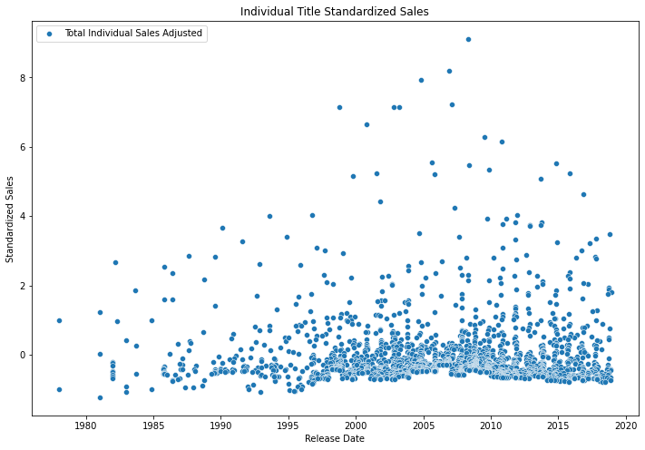

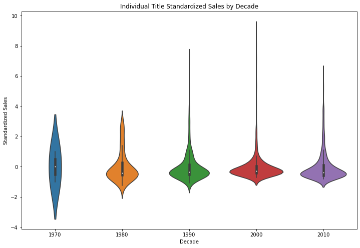

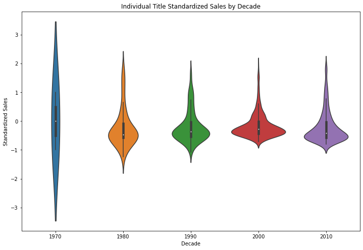

```python
#Graphing another scatterplot of individual values, this time with the adjusted total sales
tadjsalesscatter, ax6 = plt.subplots()
tadjsalesscatter.set_size_inches(12, 8)
sns.scatterplot(x=vgData['Release Date'],y=vgData['Total Sales Adj'], label="Total Individual Sales Adjusted", ax=ax6).set(title="Individual Title Standardized Sales", xlabel="Release Date", ylabel="Standardized Sales")

#Graphing a violin plot to see how much individual sales vary within a given decade
tadjsalesviolin, ax7 = plt.subplots()
tadjsalesviolin.set_size_inches(12, 8)
vgData['Decade'] = (vgData['Release Date'].dt.year - vgData['Release Date'].dt.year % 10)
sns.violinplot(x=vgData['Decade'],y=vgData['Total Sales Adj'], label="Total Individual Sales Adjusted", ax=ax7).set(title="Individual Title Standardized Sales by Decade", xlabel="Decade", ylabel="Standardized Sales")

#Graphing the same violin plot but with a more limited range to better cut out outliers
tadjsalesviolinzoomed, ax8 = plt.subplots()
tadjsalesviolinzoomed.set_size_inches(12, 8)
sns.violinplot(x=vgData.loc[vgData['Total Sales Adj'] < 2].loc[vgData['Total Sales Adj'] > -2]['Decade'],y=vgData['Total Sales Adj'], label="Total Individual Sales Adjusted", ax=ax8).set(title="Individual Title Standardized Sales by Decade", xlabel="Decade", ylabel="Standardized Sales")
```

## Clash of the Industry Titans

A large part of any industry is obviously going to be the major companies involved. The gaming industry is no different. People have famously joked about "The Console Wars," where people will argue about which company's console is the best. Competition like that fuels favoritism, and you would be hard pressed to find a frequent video game player who doesn't have a favorite developer, whether it be a little known indie darling or a name brand like Nintendo. Even just identifying industry leaders through sales can prove helpful for understanding the industry as a whole. \ \ **Finding the Big Earners:** \ First, I have defined a similar function to the yearly_total() from before, called company_total, the difference being it will go through a column and add to a publisher company based total. \ With this function, we can easily find the total number of sales per company, which can in turn be sorted to find the top 10 companies by sales. \ Having some knowledge of the gaming industry, many of the top 10 are not surprising, with Nintendo being a household name, Activision publishing the famous Call of Duty Series, and Sony being the developers of the Playstation, one of the top leading console brands. But the metric of total sales is fairly skewed, particularly in favor of game companies that have been around long enough to rack up sales (like Nintendo) or have developed far more titles than other companies (like Nintendo). We will revisit this later.

```python
#Very similar function to yearly_total(), but this time it works with companies instead of years
def company_total(col, count):
    companies = {}
    for i, row in vgData.iterrows():
        publisher = vgData.at[i,'Publisher']
        if not publisher in companies:
            companies[publisher] = 0
        if count:
            companies[publisher] += 1
        else:
            if not np.isnan(vgData.at[i, col]):
                companies[publisher] += vgData.at[i, col]

    companies = pd.DataFrame.from_dict(companies, orient = 'index')
    companies = companies.sort_index()
    companies.columns = [col]
    companies.index.set_names(["Company"])
    return companies

#Uses company_total to find the Total Sales of each company, then sorts it to find the top selling publisher
company_sales = company_total('Total Sales', False)
company_sales = company_sales.sort_values(by='Total Sales',ascending=False)
print(company_sales.head(10))
```

```
                             Total Sales
Nintendo                         1741.05
Activision                        464.80
Electronic Arts                   427.91
Sony Computer Entertainment       390.69
EA Sports                         316.10
Ubisoft                           278.88
Rockstar Games                    245.12
Capcom                            165.13
THQ                               143.64
Sega                              128.58
```

**Graphing the Big Earners:** \ With this list of the top 10 sellers, we can now graph just their sales as opposed to the whole industry. \ \ First, we graph a new scatterplot, which shows each companies' titles' sales (not standardized sales, just total sales). This graph shows that even the top companies follow the same trend of primarily normal-performing titles with several high performing hits. \ Then, we graph two violin plots (split up for visibility) to better represent the distribution of sales for each companies' titles (this time using the standardized sales to emphasize the variation of sales). Again this corroborates with what we've seen so far, the majority of titles sell around the mean with a few hits that sell hard. Just like the rest of the industry, the big players in the industry perform the same.

```
[Text(0.5, 1.0, 'Individual Title Standardized Sales by Company'),
```

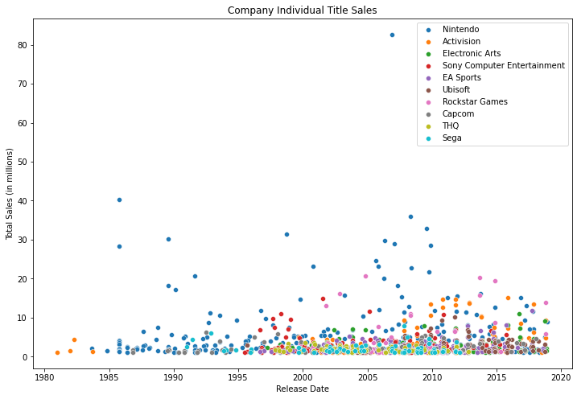

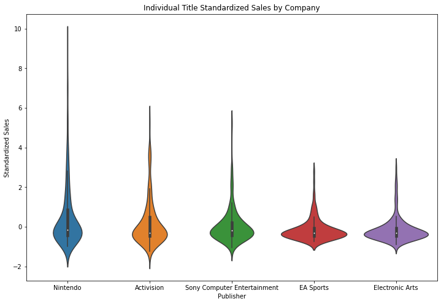

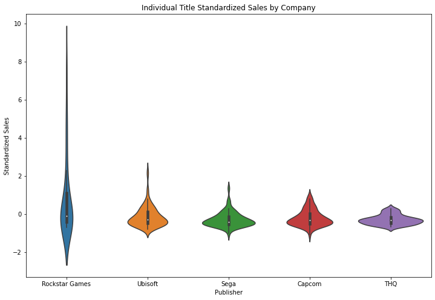

```python
#Isolate the highest 10 companies as the top_companies
top_companies = company_sales.head(10).index

#Function to check if a company is in the top 10
def top_company_check(name, start=0, end=10):
    for comp in top_companies[start:end]:
        if comp == name:
            return True
    return False

#Create new dataframe that has only the top companies in it
topc_vgData = vgData.loc[vgData['Publisher'].apply(top_company_check)]

#Graph a scatterplot of each companies' titles
toptadjsalesline, ax11 = plt.subplots()
toptadjsalesline.set_size_inches(12, 8)
for i in range(0,10):
    sns.scatterplot(x=topc_vgData.loc[topc_vgData['Publisher']==top_companies[i]]['Release Date'],y=topc_vgData['Total Sales'], label=top_companies[i], ax=ax11).set(title="Company Individual Title Sales", xlabel="Release Date", ylabel="Total Sales (in millions)")

#Graph a violin plot for each companies' titles (only graphs 5 at a time for visibility)
toptadjsalesviolin, ax9 = plt.subplots()
toptadjsalesviolin.set_size_inches(12, 8)
sns.violinplot(x=topc_vgData.loc[topc_vgData['Publisher'].apply(lambda x: top_company_check(x, 0, 5))]['Publisher'], y=topc_vgData['Total Sales Adj'], ax=ax9).set(title="Individual Title Standardized Sales by Company", xlabel="Publisher", ylabel="Standardized Sales")
#Second violin graph
toptadjsalesviolin2, ax10 = plt.subplots()
toptadjsalesviolin2.set_size_inches(12, 8)
sns.violinplot(x=topc_vgData.loc[topc_vgData['Publisher'].apply(lambda x: top_company_check(x, 5, 10))]['Publisher'], y=topc_vgData['Total Sales Adj'], ax=ax10).set(title="Individual Title Standardized Sales by Company", xlabel="Publisher", ylabel="Standardized Sales")
```

**Finding the Reliable Big Earners:** \ As mentioned before, the metric of just measuring raw sales could be biased as some companies have simply released more titles than others, and by our current metric if a company released 100 mediocre games they would beat a company that released 5 really good games. Instead, we can take the average sales/game per company by dividing each publisher's total sales by the total number of games they have produced. \ \ After doing this, we can see that the list has significantly changed with new companies entering the list and some companies falling off. This metric better protects against companies that rely on just pushing out enough normal-performing games as opposed to reliably releasing high earners. However, several members remain on both lists, such as Nintendo and Rockstar Games (most known as the creators of the Grand Theft Auto series).

```python
#Calculate the number of games produced per company and then combines it with the total sales
#into a brand new company dataframe
company_gamecount = company_total("Total Sales", True)
company_gamecount.columns = ["Games Produced"]
company_totals = company_sales.join(company_gamecount)

#Calculates the average Sales/Game
company_totals['Average Sales/Game'] = company_totals["Total Sales"]/company_totals["Games Produced"]

#Prints the Average Sales/Game of the current top 10 companies by sales
print("Top 10 Companies by Sales' Average Sales/Game:")
top10sales = company_totals.head(10)
print(top10sales)

#Prints the top 10 companies by Average Sales/Game
print("\nTop 10 Companies by Average Sales/Game:")
company_totals = company_totals.sort_values(by='Average Sales/Game', ascending=False)
top10asg = company_totals.head(10)
print(top10asg)

#Finds and prints any companies that lead in both total sales and average sales/game
consistent_champs = []
for i in top10sales.index:
    for j in top10asg.index:
        if not i in consistent_champs and i == j:
            consistent_champs.append(i)
print("\nConsistant Top Performers:")
print(consistent_champs)
```

```
Top 10 Companies by Sales' Average Sales/Game:
                             Total Sales  Games Produced  Average Sales/Game
Nintendo                         1741.05             344            5.061192
Activision                        464.80             132            3.521212
Electronic Arts                   427.91             180            2.377278
Sony Computer Entertainment       390.69             129            3.028605
EA Sports                         316.10             128            2.469531
Ubisoft                           278.88             106            2.630943
Rockstar Games                    245.12              47            5.215319
Capcom                            165.13              70            2.359000
THQ                               143.64              76            1.890000
Sega                              128.58              61            2.107869

Top 10 Companies by Average Sales/Game:
                                     Total Sales  Games Produced  \
Rockstar Games                            245.12              47
Nintendo                                 1741.05             344
Microsoft Game Studios                    120.10              25
Sony Computer Entertainment America        18.33               4
Square EA                                  18.22               4
Sony Interactive Entertainment             46.96              12
Activision                                464.80             132
Valve Corporation                           3.52               1
RedOctane                                  27.18               8
Microsoft                                  16.92               5

                                     Average Sales/Game
Rockstar Games                                 5.215319
Nintendo                                       5.061192
Microsoft Game Studios                         4.804000
Sony Computer Entertainment America            4.582500
Square EA                                      4.555000
Sony Interactive Entertainment                 3.913333
Activision                                     3.521212
Valve Corporation                              3.520000
RedOctane                                      3.397500
Microsoft                                      3.384000

Consistant Top Performers:
['Nintendo', 'Activision', 'Rockstar Games']
```

## Predicting (or at least tricking a computer into predicting)

Now that we have a better understanding of the industry, we can try training a model to predict roughly how well a game will sell given some basic information about it. A model like this could be useful in the real world for predicting the potential success of a game before or during development (although from an artistic standpoint I really hope there is more driving the creation of a game than a computer telling a company they can make money). \ \ **Preparing the Training Data:** \ From the dataset we have been working with, it wouldn't make sense to predict a game's sales with regional sales data (because it wouldn't be much of a prediction more just basic addition). The model has to be limited to data that a game would have before or at least close to launch. The console, publisher, developer, and the release year can all be determined ahead of time, and critic scores are often released close enough to launch as critics get their copies ahead of time that its fair to predict from. \ \ To prepare the data for training, each of the aformentioned columns is added to a dataframe, and the console, publisher, and developer are all encoded with one-hot encoding in order to be compatible with sci-kit learn's models (this results in a comically large dataframe). The release date is simplified down to a year, and the critic score is set to 0 if the game does not have one.\ The standardized total sales (which are being predicted in this case) are labeled as "Strongly Positive", "Positive", "Negative", or "Strongly Negative"\ After all the data is prepared, the data is split into 75% training data and 25% testing data

```python
#Begin preparing the X data by one hot encoding
X = vgData[['Console', 'Publisher', 'Developer', 'Critic Score', 'Release Date']]
X = X.join(pd.get_dummies(X['Console']))
X.pop('Console')
X = X.join(pd.get_dummies(X['Publisher']),lsuffix="Pub")
X.pop('Publisher')
X = X.join(pd.get_dummies(X['Developer']),lsuffix="Dev")
X.pop('Developer')
#Simplify release date to year
X['Release Date'] = X['Release Date'].dt.year
#Replace NaN critic scores with 0
X['Critic Score'] = X['Critic Score'].apply(lambda x: 0 if np.isnan(x) else x)
X.fillna(0, inplace=True)

#label the standardized sales to be guessed
def label_sales(sales):
    if sales > 2:
        return "Strongly Positive"
    elif sales > 0:
        return "Positive"
    elif sales > -2:
        return "Negative"
    else:
        return "Strongly Negative"
ts = vgData['Total Sales Adj'].apply(label_sales)
ts.fillna(0, inplace=True)

# Splits up the data for training (75%) and testing (25%)
X_train, X_test, ts_train, ts_test = train_test_split(X, ts, test_size = 0.25)
```

**Model 1: Random Forest:** \ [This model comes from sci-kit learn](https://scikit-learn.org/stable/modules/generated/sklearn.ensemble.RandomForestClassifier.html) and works by fitting several decision trees to different portions of the training data. It makes sense for this goal because of the decent number of features being inputted into the model (random forests work best with more features). The n_estimators is optimized using a GridSearchCV.

```python
#Training the random forest and predicting with it
forest_tuned_parameters = [{'n_estimators' : range(20,200,40)}]
forest = GridSearchCV(RandomForestClassifier(), forest_tuned_parameters, cv=10)
#forest = RandomForestClassifier(n_estimators = 200)
forest.fit(X_train, ts_train)
forest_predictions = forest.predict(X_test)
```

**Model 2: K Nearest Neighbors:** \ [This model comes from sci-kit learn](https://scikit-learn.org/stable/modules/generated/sklearn.neighbors.KNeighborsClassifier.html) and it works by identifying the k nearest datapoints or 'neighbors' to a point and classifying based on their values. It fits for this project because it accounts for brand value in that if a game is made by the same developer and publisher as a previous game, it is likely a sequel or in the same brand. The n_neighbors parameter is optimized via a GridSearchCV.

```python
#Training the k nearest neighbors and determine the best value for k
tuned_parameters = [{'n_neighbors' : range(1,100,10)}]
knnr = GridSearchCV(KNeighborsClassifier(), tuned_parameters, cv=10)
knnr.fit(X_train, ts_train);
```

**Judgement Day:** \ After running both a manual check on the random forest and the 10-fold cross-validation on both models, both prove to work fairly effectively, earning an average score of above 70% and low standard deviations. The random forest model seems to be more effective overall, but both prove quite effective overall. This shows that it is possible to predict game sales based on prior history given some descriptive features of the game.

```python
#Manually check the accuracy of the random forest
forest_prediction_accuracy = 0
for i in range(0, len(forest_predictions)):
    if forest_predictions[i] == ts_test.iloc[i]:
        forest_prediction_accuracy += 1
print("Manually Checked Random Forest Accuracy: ")
print(forest_prediction_accuracy/len(forest_predictions))

#Performs a 10-fold cross-validation on both the forest and the k nearest neighbors
tenfold = KFold(n_splits=10, shuffle=True)
forest_scores = cross_validate(forest, X, ts, cv=tenfold)
knnr_scores = cross_validate(knnr, X, ts, cv=tenfold)

# Prints the mean of each algorithm's scores
print("Average Random Forest Score", (np.mean(forest_scores['test_score'])))
print("Average K Nearest Neighbors Score", (np.mean(knnr_scores['test_score'])))
# Prints the standard deviation of each algorithm's scores
print("Standard Deviation of Random Forest's Scores", (np.std(forest_scores['test_score'])))
print("Standard Deviation of K Nearest Neighbors' Scores", (np.std(knnr_scores['test_score'])))
```

```
Manually Checked Random Forest Accuracy:
0.754
```

[output not shown]

```
Average Random Forest Score 0.7453718592964824
Average K Nearest Neighbors Score 0.7263743718592964
Standard Deviation of Random Forest's Scores 0.02444434333465721
Standard Deviation of K Nearest Neighbors' Scores 0.01909155622924868
```

## Conclusions

After scraping, analyzing, and training with this video game sales data, I hope you have learned a lot, both about the video game industries' historical performance and (arguably more importantly) about the data science pipeline and the process of data analysis and model training. Being able to apply these skills in industries can be very beneficial, as shown by the model we trained, and I hope that you will be able to apply these skills to projects of your own, wether for profit or for fun.\ \ **Thank you for reading through this tutorial, and I hope you learned a lot!** \ **- Martin Blurton-Jones**